# LCL Fiber-seq: testing Leiden clustering parameters

Crystal Shan

2026-09-15

# Region and fixed settings

This notebook tests only the **rank-1 AS-FIRE region** selected in `leiden_LCL.Rmd`. It reads the existing clustering input and annotations, preserving the retained full-span, phased heterozygous reads, m6A sites, focal SNP, and sample information. Only the number of graph neighbours (`k`) and Leiden resolution change.

Other settings remain unchanged: no binning, no imputation, Manhattan distance, the union k-nearest-neighbour graph, exponential affinity weights with automatic sigma (the mean retained neighbour distance), modularity objective, and seed 1. Automatic sigma is recalculated for each `k`, as in the original workflow. UMAP is calculated **once**, with Manhattan distance, 15 neighbours, minimum distance 0.1, random initialization, and the original plotting seed. Its coordinates are reused for every parameter pair.

All results stay in memory. Running a figure chunk displays its plot. Knitting embeds plots in the self-contained HTML; temporary figure files are placed in R’s temporary directory. No separate analysis tables, RDS files, or plot exports are written.

```r
signature <- readRDS(file.path(input_dir, "summary tables/selection_signature.rds"))
region <- signature$regions[signature$regions$rank == 1L, , drop = FALSE]
stopifnot(nrow(region) == 1L)
result_paths <- readRDS(file.path(input_dir, "summary tables/fiberseq_result_paths.rds"))
baseline <- fiberseq_display_result(readRDS(result_paths[[region$region_id]]))
stopifnot(identical(baseline$region$region_id, region$region_id),
  baseline$params$window_size == 0L, !baseline$params$impute_missing,
  baseline$params$k_neighbors == 10L, baseline$params$resolution == 1,
  baseline$params$seed == 1L,
  identical(rownames(baseline$feat_mat), baseline$assignments$RID),
  !anyNA(baseline$feat_mat))
knitr::kable(region[, c("rank", "region_id", "focal_snp", "peak_name",
  "analysis_start", "analysis_end")])
```

| rank | region_id | focal_snp | peak_name | analysis_start | analysis_end |
| --- | --- | --- | --- | --- | --- |
| 1 | rank01_rs12470189_chr2_119290945_119291178 | rs12470189 | chr2_119290945_119291178 | 119290056 | 119292055 |

# Five parameter pairs

The preliminary sweep produced 1, 2, 3, 5, and 6 clusters for these pairs, respectively. The table below is recalculated when this notebook runs. Cluster labels are assigned by decreasing size independently for each pair: the same colour across panels does not imply identical cluster membership.

```r
parameter_pairs <- data.frame(
  k = c(10L, 10L, 5L, 10L, 5L),
  resolution = c(0.1, 1, 1, 1.5, 1.5))
parameter_pairs$label <- sprintf("k = %d; resolution = %g",
  parameter_pairs$k, parameter_pairs$resolution)

# Use the saved feature matrix directly, so the reads and features cannot change.
graphs <- setNames(lapply(unique(parameter_pairs$k), function(k) {
  manhattan_knn_graph(baseline$feat_mat, k_neighbors = k,
    sigma = NULL, verbose = FALSE)
}), as.character(unique(parameter_pairs$k)))

results <- lapply(seq_len(nrow(parameter_pairs)), function(i) {
  pair <- parameter_pairs[i, ]
  knn <- graphs[[as.character(pair$k)]]
  part <- leiden_partition(knn$graph, resolution = pair$resolution,
    n_iterations = -1L, seed = baseline$params$seed)
  membership <- part$membership[baseline$assignments$RID]
  stopifnot(!anyNA(membership))
  cluster_order <- names(sort(table(membership), decreasing = TRUE))
  result <- baseline
  result$assignments$cluster <- factor(
    paste0("cluster", match(as.character(membership), cluster_order)),
    levels = paste0("cluster", seq_along(cluster_order)))
  result$n_clusters <- length(cluster_order)
  result$profiles <- do.call(rbind, lapply(levels(result$assignments$cluster), function(cl) {
    colMeans(result$feat_mat[result$assignments$cluster == cl, , drop = FALSE])
  }))
  rownames(result$profiles) <- levels(result$assignments$cluster)
  result$graph <- knn$graph
  result$params$k_neighbors <- pair$k
  result$params$k_eff <- knn$k_eff
  result$params$resolution <- pair$resolution
  result$params$sigma <- knn$sigma
  result$params$mean_knn_dist <- knn$mean_knn_dist
  result$params$quality <- part$quality
  # The saved signature describes the baseline, not this in-memory rerun.
  result$analysis_signature <- NULL
  result
})
names(results) <- parameter_pairs$label
baseline_index <- which(parameter_pairs$k == 10L & parameter_pairs$resolution == 1)
stopifnot(identical(results[[baseline_index]]$assignments, baseline$assignments),
  all(vapply(results, function(x) identical(x$feat_mat, baseline$feat_mat), logical(1))))
parameter_pairs$n_clusters <- vapply(results, function(x) x$n_clusters, integer(1))
parameter_pairs$smallest_cluster <- vapply(results, function(x)
  min(as.integer(table(x$assignments$cluster))), integer(1))
parameter_pairs$largest_cluster <- vapply(results, function(x)
  max(as.integer(table(x$assignments$cluster))), integer(1))
knitr::kable(parameter_pairs[, c("k", "resolution", "n_clusters",
  "smallest_cluster", "largest_cluster")])
```

| k | resolution | n_clusters | smallest_cluster | largest_cluster |
| --- | --- | --- | --- | --- |
| 10 | 0.1 | 1 | 255 | 255 |
| 10 | 1.0 | 2 | 120 | 135 |
| 5 | 1.0 | 3 | 49 | 117 |
| 10 | 1.5 | 5 | 27 | 97 |
| 5 | 1.5 | 6 | 21 | 77 |

```r
cat("Retained reads:", nrow(baseline$feat_mat),
  " | m6A features:", ncol(baseline$feat_mat),
  " | Baseline assignments reproduced exactly.\n")
```

```
## Retained reads: 255  | m6A features: 876  | Baseline assignments reproduced exactly.
```

```r
fixed_embedding <- fiberseq_umap(baseline, seed = signature$view_params$seed,
  n_neighbors = 15L, min_dist = 0.1)
fixed_embedding <- fixed_embedding[, c("RID", "UMAP1", "UMAP2")]
stopifnot(identical(fixed_embedding$RID, baseline$assignments$RID))

# These two requested figure types use 130-160 bp nucleosomes and m6A.
# Extract nucleosomes once, without invoking any cache or export functions.
selected_samples <- lcl_region_samples(region, signature$sample_table)
footprints <- extract_nucleosomes(selected_samples, region, baseline$assignments)
all_sample_colors <- sample_palette(signature$sample_table$sample_name)
short_colors <- all_sample_colors[names(all_sample_colors) %in%
  sub("_.*$", "", baseline$assignments$sample_name)]
sample_names <- signature$sample_table$sample_name
sample_colors <- setNames(unname(all_sample_colors[sub("_.*$", "", sample_names)]), sample_names)
sample_colors <- sample_colors[names(sample_colors) %in% baseline$assignments$sample_name]
```

# Fixed UMAP coloured by clustering result

Every point represents the same read at the same coordinates in all five panels. The UMAP neighbour setting remains 15; `k` in each title refers to the clustering graph only.

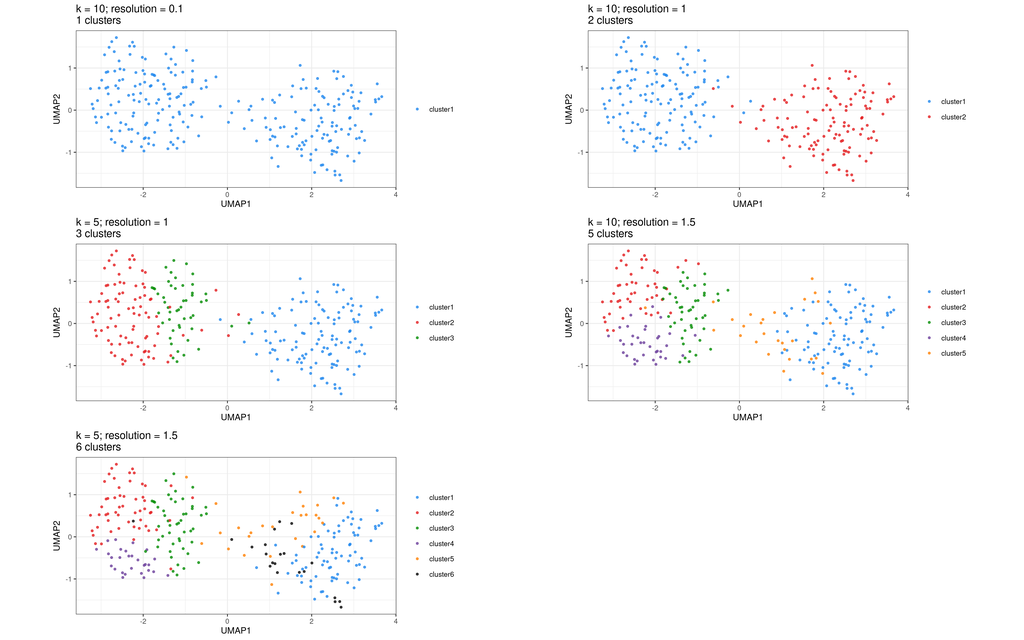

```r
umap_panels <- lapply(seq_along(results), function(i) {
  result <- results[[i]]
  embedding <- data.frame(result$assignments, fixed_embedding[, c("UMAP1", "UMAP2")])
  plot_umap(embedding, "cluster",
    cluster_id_palette(levels(result$assignments$cluster)),
    paste0(parameter_pairs$label[i], "\n", result$n_clusters, " clusters"),
    show_legend = TRUE)
})
print(cowplot::plot_grid(plotlist = umap_panels, ncol = 2))
```

# Heatmap of number of clusters

Only the five selected pairs are tested here. The grey cell is untested.

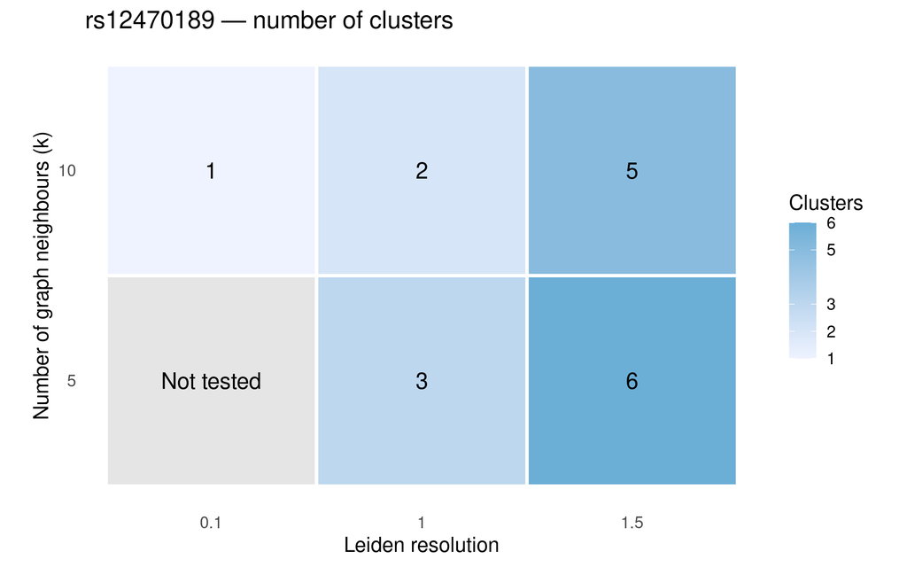

```r
count_grid <- merge(expand.grid(k = sort(unique(parameter_pairs$k)),
  resolution = sort(unique(parameter_pairs$resolution))),
  parameter_pairs[, c("k", "resolution", "n_clusters")],
  by = c("k", "resolution"), all.x = TRUE)
count_grid$label <- ifelse(is.na(count_grid$n_clusters), "Not tested", count_grid$n_clusters)
ggplot2::ggplot(count_grid, ggplot2::aes(factor(resolution), factor(k), fill = n_clusters)) +
  ggplot2::geom_tile(color = "white", linewidth = 1) +
  ggplot2::geom_text(ggplot2::aes(label = label), size = 5) +
  ggplot2::scale_fill_gradient(low = "#eff3ff", high = "#6baed6",
    na.value = "grey90", breaks = sort(unique(parameter_pairs$n_clusters))) +
  ggplot2::labs(x = "Leiden resolution", y = "Number of graph neighbours (k)",
    fill = "Clusters", title = paste(region$focal_snp, "— number of clusters")) +
  ggplot2::coord_equal() + ggplot2::theme_minimal(base_size = 13) +
  ggplot2::theme(panel.grid = ggplot2::element_blank())
```

# Per-pair figures

`fiberseq_haplotype_example` combines the fixed UMAP coloured by cluster, sample, and focal allele; cluster proportions; per-cluster m6A and nucleosome profiles; and within-cluster sample and allele proportions, matching the original layout.

`heatmap_m6a_footprints` uses the original genomic heatmap function and settings: m6A calls per read, cluster/sample/focal-allele annotations, and m6A profiles above the heatmap. Despite its original filename, this heatmap does not overlay footprint intervals. Nucleosome occupancy is shown in the haplotype example.

```r
# Assemble the original haplotype-example layout without its file-saving wrapper.
fiberseq_haplotype_example <- function(result, title) {
  tables <- fiberseq_tables(result, footprints)
  cluster_colors <- cluster_id_palette(tables$groups)
  allele_colors <- fiberseq_category_palette(result$allele_display_levels)
  profiles <- plot_fiberseq_profiles(tables, result$region, result$markers,
    cluster_colors, sample_colors, allele_colors, title)
  stopifnot(identical(fixed_embedding$RID, result$assignments$RID))
  embedding <- data.frame(result$assignments, fixed_embedding[, c("UMAP1", "UMAP2")])
  pc <- plot_umap(embedding, "cluster", cluster_colors, "UMAP: cluster")
  ps <- plot_umap(embedding, "sample_name", sample_colors, "UMAP: LCL sample")
  pa <- plot_umap(embedding, "allele_display", allele_colors, "UMAP: Focal SNP allele")
  counts <- tables$counts
  counts$cluster <- factor(counts$cluster, levels = tables$groups)
  counts$label <- sprintf("%s\nn=%d (%.1f%%)", counts$cluster, counts$n_reads, 100 * counts$proportion)
  rgb <- grDevices::col2rgb(cluster_colors) / 255
  text_colors <- setNames(ifelse(colSums(rgb * c(.299, .587, .114)) < .5,
    "white", "black"), names(cluster_colors))
  pie <- ggplot2::ggplot(counts, ggplot2::aes(x = "", y = proportion, fill = cluster)) +
    ggplot2::geom_col(width = 1, color = "white", position = ggplot2::position_stack(reverse = TRUE)) +
    ggplot2::geom_text(ggplot2::aes(label = ifelse(proportion >= .03,
      sprintf("%.1f%%", 100 * proportion), ""), color = cluster),
      position = ggplot2::position_stack(vjust = .5, reverse = TRUE), size = 3) +
    ggplot2::scale_color_manual(values = text_colors, guide = "none") +
    ggplot2::coord_polar(theta = "y") +
    ggplot2::scale_fill_manual(values = cluster_colors, labels = counts$label) +
    ggplot2::labs(title = paste0("Cluster proportions: ", nrow(embedding), " reads"), fill = NULL) +
    ggplot2::theme_void() + ggplot2::theme(legend.position = "right",
      legend.text = ggplot2::element_text(size = 8))
  cluster_labels <- paste0(tables$groups, " (n=", tables$counts$n_reads, ")")
  legends <- list(fiberseq_legend(cluster_colors, "Cluster", 5, cluster_labels),
    fiberseq_legend(sample_colors, "LCL sample", 6, sub("_.*$", "", names(sample_colors))),
    fiberseq_legend(allele_colors, "Focal SNP allele", 3))
  lh <- vapply(legends, fiberseq_legend_height, numeric(1))
  heading <- cowplot::ggdraw() + cowplot::draw_label(
    paste(result$region$annotation, title, sep = "\n"), size = 12)
  overview <- cowplot::plot_grid(plotlist = c(list(heading,
    cowplot::plot_grid(pc, ps, pa, pie, ncol = 2)), legends),
    ncol = 1, rel_heights = c(.65, 8, lh))
  cowplot::plot_grid(overview, profiles$plot, ncol = 1,
    rel_heights = c(8.65 + sum(lh), profiles$height))
}

heatmap_m6a_footprints <- function(result, title) {
  heatmap <- plot_genomic_cluster_heatmap(result, result$region, short_colors,
    include_haplotype = TRUE, variants = result$variants,
    show_cluster_profiles = TRUE, cluster_label = title)
  ComplexHeatmap::draw(heatmap)
  invisible(NULL)
}
```

## k = 10, resolution = 0.1

### fiberseq_haplotype_example

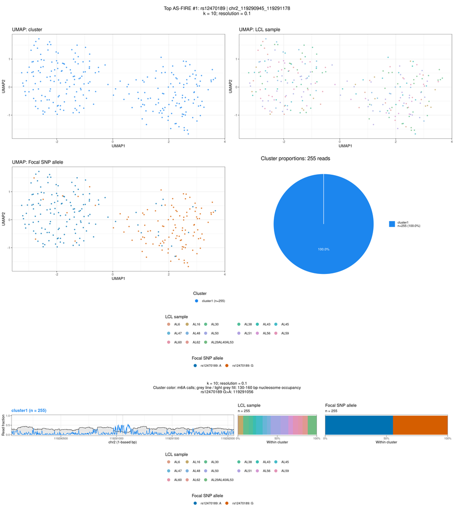

```r
print(fiberseq_haplotype_example(results[[1]], parameter_pairs$label[1]))
```

### heatmap_m6a_footprints

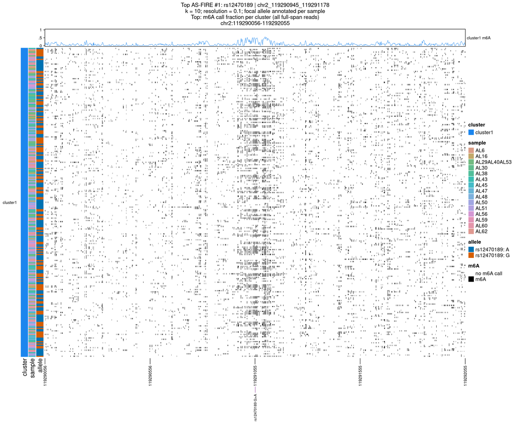

```r
heatmap_m6a_footprints(results[[1]], parameter_pairs$label[1])
```

## k = 10, resolution = 1 (baseline)

### fiberseq_haplotype_example

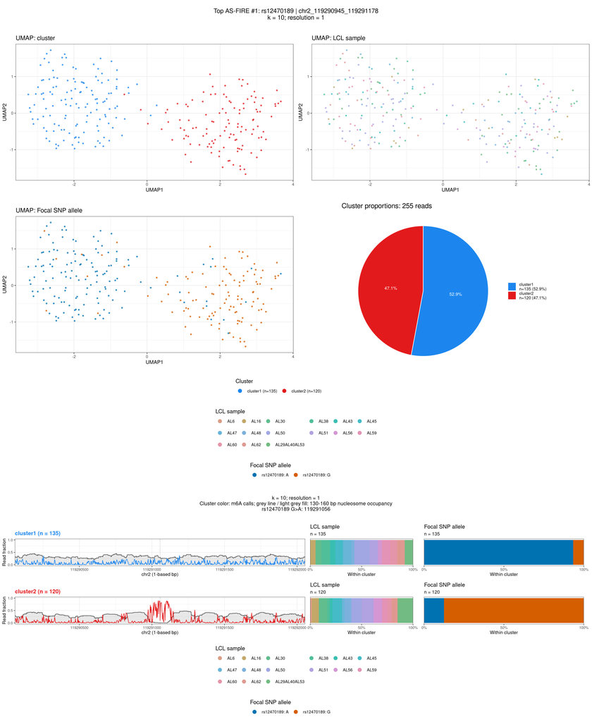

```r
print(fiberseq_haplotype_example(results[[2]], parameter_pairs$label[2]))
```

### heatmap_m6a_footprints

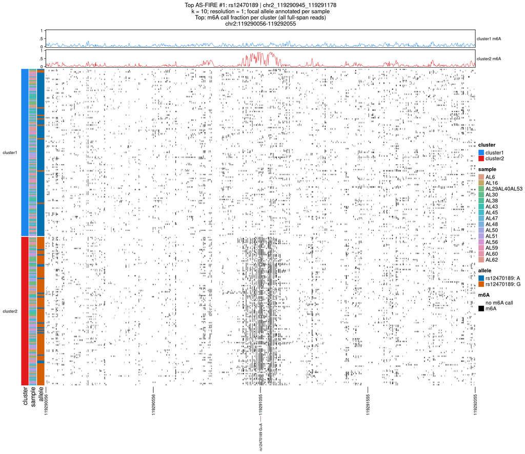

```r
heatmap_m6a_footprints(results[[2]], parameter_pairs$label[2])
```

## k = 5, resolution = 1

### fiberseq_haplotype_example

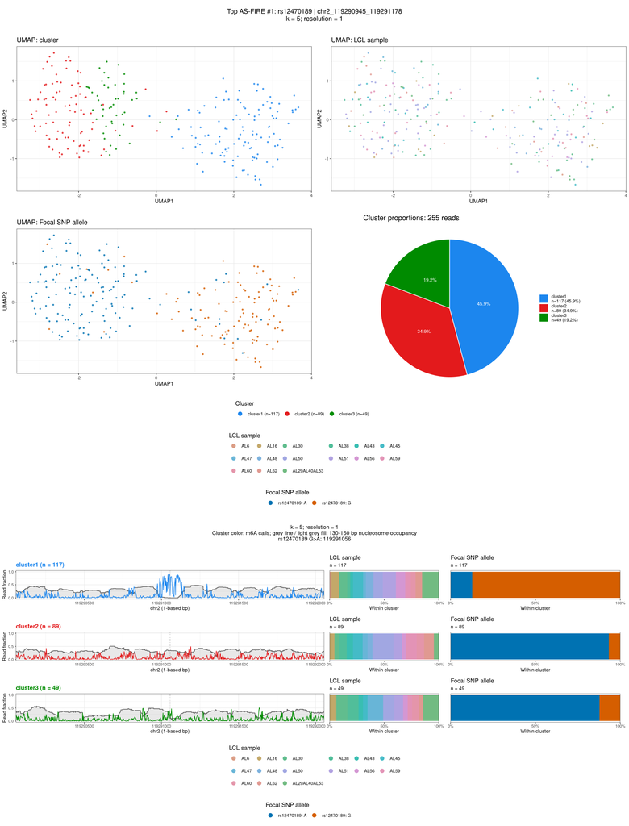

```r
print(fiberseq_haplotype_example(results[[3]], parameter_pairs$label[3]))
```

### heatmap_m6a_footprints

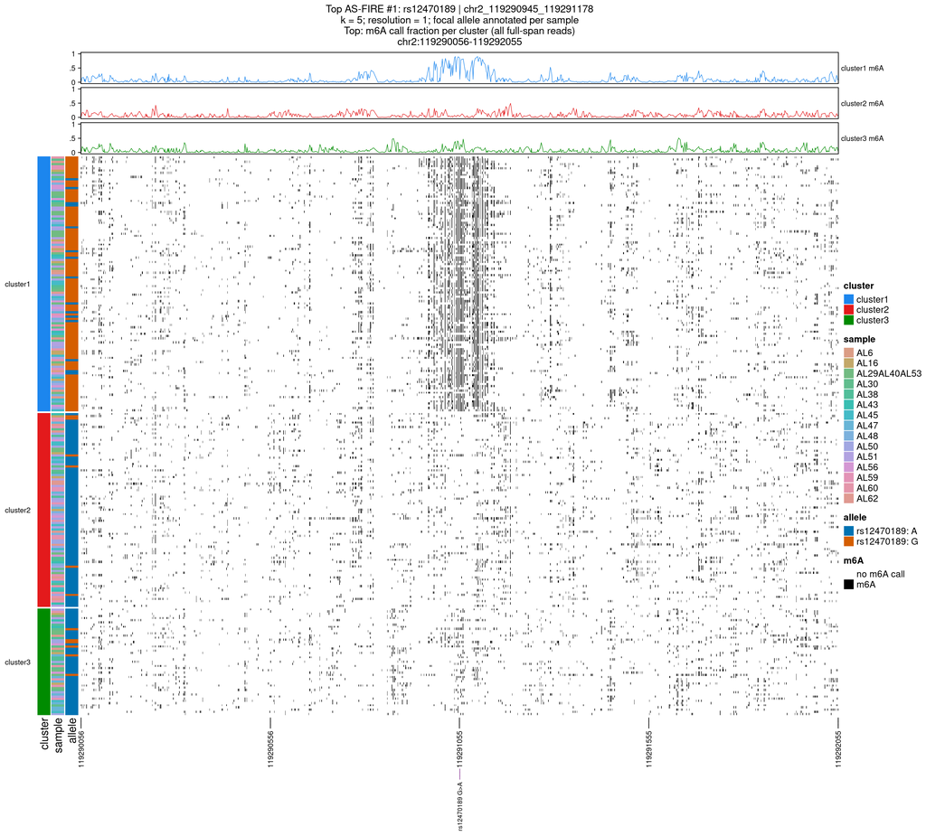

```r
heatmap_m6a_footprints(results[[3]], parameter_pairs$label[3])
```

## k = 10, resolution = 1.5

### fiberseq_haplotype_example

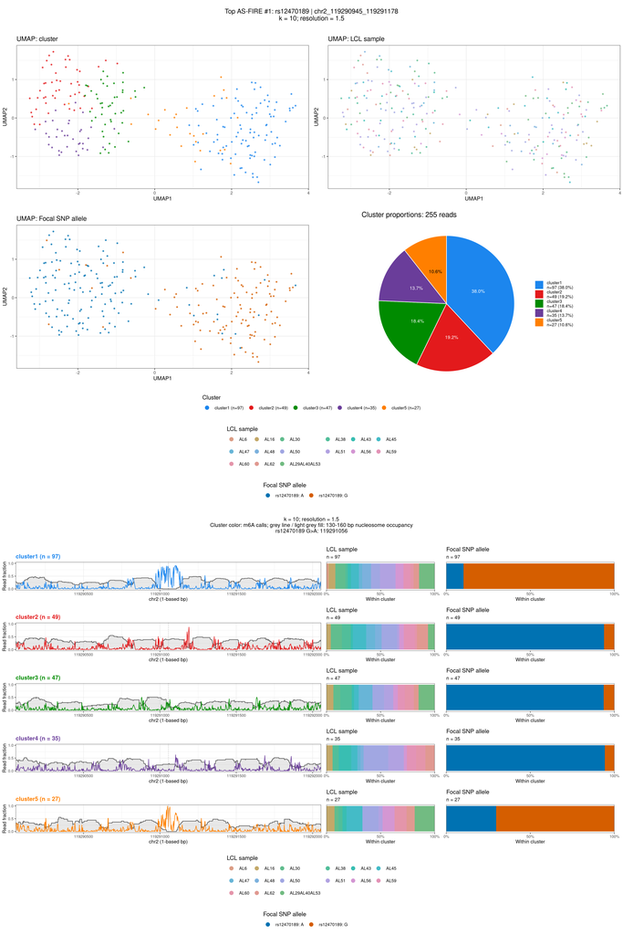

```r
print(fiberseq_haplotype_example(results[[4]], parameter_pairs$label[4]))
```

### heatmap_m6a_footprints

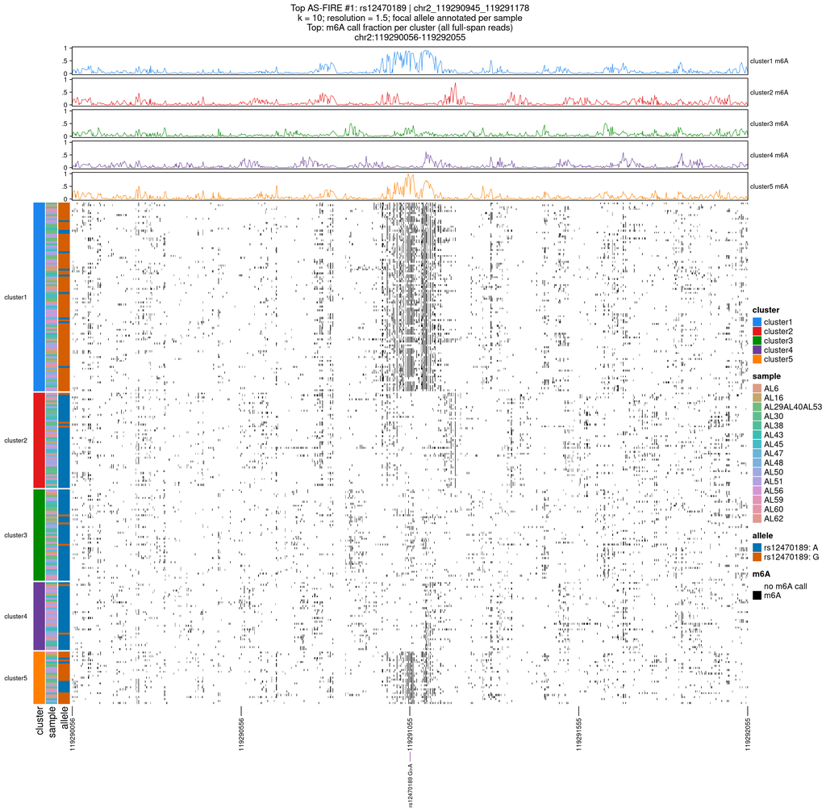

```r
heatmap_m6a_footprints(results[[4]], parameter_pairs$label[4])
```

## k = 5, resolution = 1.5

### fiberseq_haplotype_example

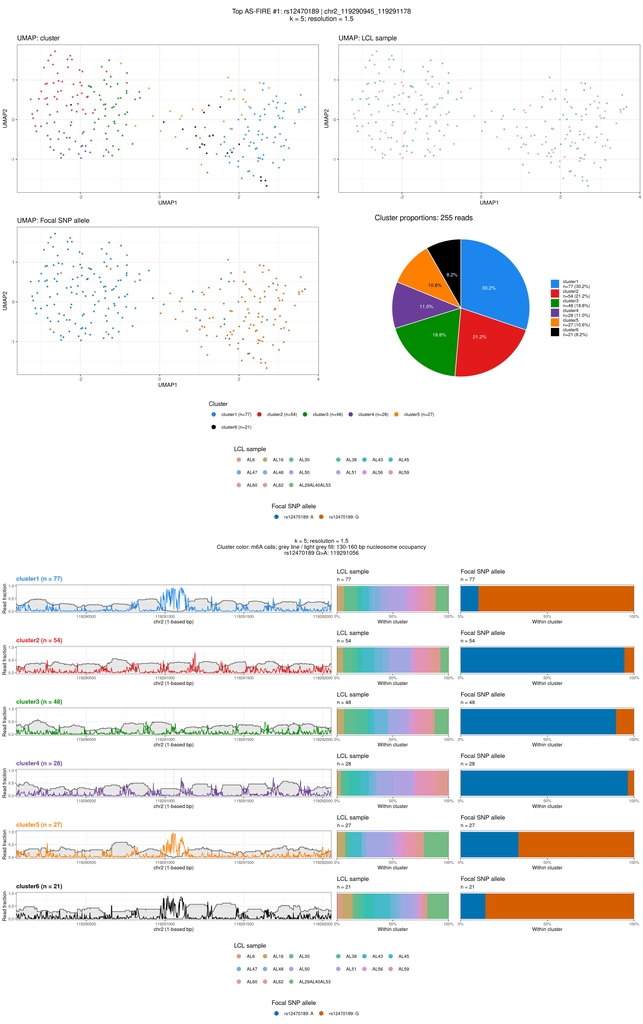

```r
print(fiberseq_haplotype_example(results[[5]], parameter_pairs$label[5]))
```

### heatmap_m6a_footprints

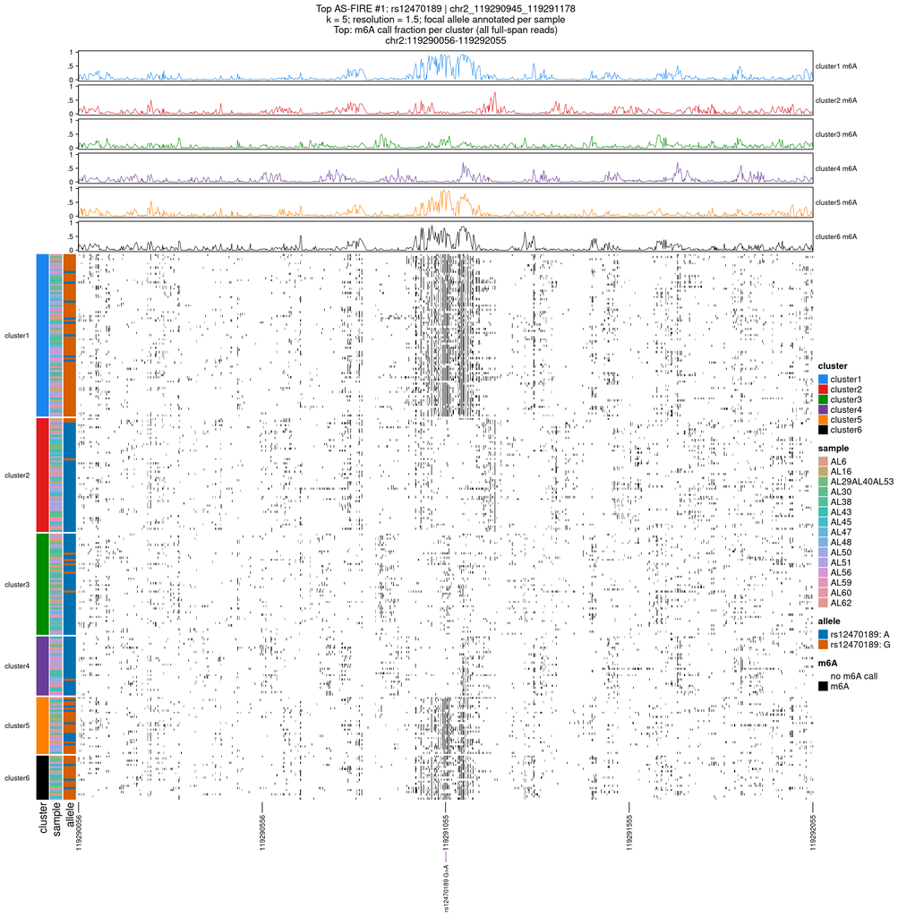

```r
heatmap_m6a_footprints(results[[5]], parameter_pairs$label[5])
```